# Evolution du nombre d’exploitations

Exploitations agricoles

**Source: Agreste - Recensements agricoles**

En 2020, la France compte 416 400 « exploitations agricoles », 20 % de moins qu’il y a 10 ans, selon les résultats du dernier recensement agricole.

# **Evolution du nombre d’exploitations agricoles en france**

En 2020, la France ? Y compris les 5 départements d’outre-mer : Guadeloupe, Martinique, Guyane, la Réunion et Mayotte (Mayotte est recensée depuis 2020). compte **416 436** "exploitations agricoles" ? Unité de production agricole disposant d’une gestion courante propre et dépassant un seuil minimum de superficie - 1 ha ou 20 ares de cultures spécialisées - ou de production, estimée en cheptel ou volume. selon les résultats du dernier recensement agricole

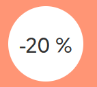

En **métropole**, elles sont **390 000**. C’est **100 000** de moins en 10 ans, soit une baisse de **20%**

Pour autant, l’agriculture est toujours présente dans nos paysages : la superficie agricole utilisée ne recule que de 1 % depuis 2010…

Pour autant, l’agriculture est toujours présente dans nos paysages : la superficie agricole utilisée ? La superficie agricole utilisée (SAU) comprends les terres arables (y compris pâturages temporaires, jachères, cultures sous abri, jardins familiaux...), les surfaces toujours en herbe et les cultures permanentes (vignes, vergers...). ne recule que de 1 % depuis 2010...

Les exploitations se regroupent, elles sont moins nombreuses tout en travaillant un espace équivalent. Ainsi, le poids des exploitations de moins de 20 ha baisse de 43 % à 38 %.

De moins en moins d’exploitations : cette tendance observée au travers des recensements agricoles se poursuit : elles étaient 4 fois plus nombreuses en métropole en 1970.

Si la baisse du nombre d’exploitations est une constante depuis 50 ans, elle a été maximale entre 1988 et 2000, avec une chute de 350 000 en douze ans.

Si la baisse du nombre d’exploitations est une constante depuis 50 ans, elle a été maximale entre 1988 et 2000, ? La mise en oeuvre des "quotas laitiers" et des mesures d'incitation à la retraite ont favorisé les regroupements. avec une chute de 350 000 en douze ans.

## **Nombre d’exploitations agricoles en métropole**

[figure not shown]

## **4 fois moins d’exploitations qu’en 1970**

[figure not shown]

## **Forte concentration entre 1988 et 2000**

[figure not shown]

## **Evolution annuelle moyenne du nombre d’exploitations**

[figure not shown]

Depuis, la baisse s’atténue progressivement. Elle s’établit à -2.3 % par an sur la période 2010-2020 (contre -3 % entre 2000 et 2010)

Dans presque toutes les spécialisation, le nombre d’exploitations recule entre 2010 et 2020, excepté pour “Horticulture-maraichage”.

C’est dans les exploitations spécialisées en élevage que la baisse est la plus forte : -30 % (correspondant à -63 500 exploitations), preque les 2/3 de la diminution totale.

L’élevage de bovins est particulièrement concerné : -33 000 exploitations, soit -27 %. Il perd le premier range qu’il détenait en 2010, qui revient à la spécialisation “Grandes cultures”.

## **Évolution du nombre d’exploitations par spécialisation**

[figure not shown]

## **Évolution du nombre d’exploitations par spécialisation**

[figure not shown]

## **Évolution du nombre d’exploitations par spécialisation**

[figure not shown]

## **Évolution du nombre d’exploitations par spécialisation**

[figure not shown]

# Comment se traduisent ces évolution générales dans les territoires ?

Dans une grande façade Ouest, le nombre d’exploitations en Normandie, Bretagne, Pays de la Loire et Nouvelle-Aquitaine par exemple se réduit plus fortement…

…que dans les Hauts-de-France, l’Île-de-France ou l’ancienne Champagne-Ardenne.

Tous les territoires sont concernés par la baisse du nombre d’exploitations excepté la Corse et la Guyane, qui se distinguent par une légère augmentation.

À l’opposé, le nombre d’exploitations baisse le plus fortement dans trois départements de l’Est de la France métropolitaine : Vosges, Territoire-de-Belfort et Alpes-Maritimes.

Dans ces départements se poursuit ces dix dernières années une tendance plus ancienne, avec une diminution plus prononcée qu’en moyenne.

Les Vosges comptent 1 000 exploitations de moins qu’en 2010, évolution plus forte que celle observée entre 2000 et 2010 (-4 % par an contre -3,2 %).

*Vosges : un tiers d’exploitations en moins entre 2010 et 2020*

[figure not shown]

*Comparaison : indice base 100*

[figure not shown]

Les Alpes-Maritimes détonnent au sein de la région Sud. Beaucoup de petites exploitations de fruits, gérées par des exploitants retraités ou proches de la retraite en 2010, ont disparu.

*Alpes-Maritimes : dix fois moins d’exploitations en 50 ans*

[figure not shown]

*Comparaison : indice base 100*

[figure not shown]

En Corse le nombre d’exploitations se redresse légèrement

*Corse : légère augmentation entre 2010 et 2020*

[figure not shown]

*Comparaison : indice base 100*

[figure not shown]

Le profil du département de la Marne est atypique : le nombre d’exploitations est quasi stable depuis 50 ans

*Marne : seulement 20 % d’exploitations en moins en 50 ans*

[figure not shown]

*Comparaison : indice base 100*

[figure not shown]

Dans cette terre de champagne, on compte en 2020, 9 300 exploitations viticoles, soit 70 % de l’ensemble. Elles occupent pour la plupart moins de 20 ha. C’était déjà le cas en 1970.

Cette stabilité explique que la Marne soit devenue en 2020 le 1er département de France en nombre d’exploitations, alors qu’il n’était que le 45e il y a 50 ans !

[interactive chart not shown]

# **Le top 6 des départements en 2020**

[figure not shown]

Il y a 50 ans, c’est la Bretagne et ses proches voisins qui marquaient la tête du classement.

En 2020, la distribution géographique des exploitations est assez proche, bien qu’un peu plus homogène, avec en particulier l’apparition de la Marne, des Pyrénées-Atlantiques et de l’Aveyron parmi les 6 premiers départements.

## **1970**

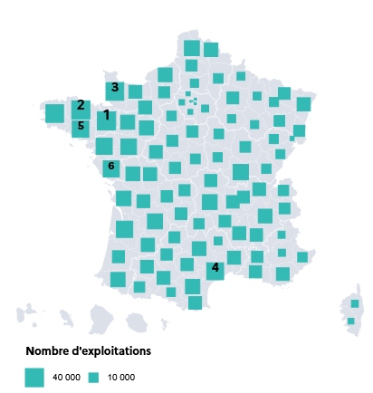

## **2020**

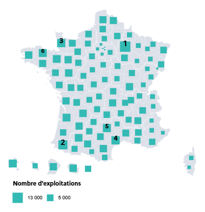

**Pour en savoir plus sur le sujet :**

[🐮 Site Agreste 🐮](https://agreste.agriculture.gouv.fr/agreste-web/)

**Pour aller voir d’autres DataViz :**

[📉 Accueil VizAgreste 📉](https://vizagreste.agriculture.gouv.fr/)